# Проект: Spotify

**Цель исследования:**

1. Построить модель, которая сможет предсказать уровень популярности песни.

   **Ход исследования:**

### Описание признаков

- Unnamed: 0 - номер строки ( нужно удалить )
- track_id - id песни
- artists - исполнитель песни
- album_name - название альбома, в котором содержится данная песня
- track_name - название песни
- popularity - популярность песни ( насколько песня популярна от 0 до 100 )
- duration_ms - длительность песни в миллисекундах
- explicit - является ли песня "откровенной" ( ненормативная лексика, ссылки на физическое или психологическое насилие, и так далее )
- danceability - числовое значение в диапазоне от 0,0 до 1,0, которое отражает уровень в том, что трек является танцевальным
- energy - числовое значение в диапазоне от 0,0 до 1,0, которое отражает уровень в том, что трек является энергичным
- key - тональность песни ( от "До мажор" до "Си мажор" )
- loudness - числовое значение в диапазоне от -50 до 4, которое отражает уровень в том, что трек является громким
- mode - тип тональности ( минор или мажор )
- speechiness - числовое значение в диапазоне от 0,0 до 1,0, которое отражает процентное соотношение слов и инструментала в песни
- acousticness - числовое значение в диапазоне от 0,0 до 1,0, которое отражает уровень в том, что трек является акустическим
- instrumentalness - насколько вероятно, что музыка не содержит вокала, произнесенного устно.
- liveness - числовое значение в диапазоне от 0,0 до 1,0, которое отражает уровень в том, что трек является инструментальным
- valence - числовое значение в диапазоне от 0,0 до 1,0, которое отражает уровень в том, что трек описывает музыкальную позитивность
- tempo - скорость, с которой проигрывается музыкальное произведение
- time_signature - сколько долей содержится в каждом такте музыкального произведения
- track_genre - жанр песни

# Шаг 1. Загрузка данных

```python
import seaborn as sns
from sklearn.preprocessing import LabelEncoder
from sklearn.neighbors import KNeighborsClassifier
from sklearn.tree import DecisionTreeClassifier
from sklearn.linear_model import LogisticRegression
from sklearn.svm import SVC
from sklearn.model_selection import GridSearchCV
from sklearn.multiclass import OneVsRestClassifier
from sklearn.linear_model import LinearRegression
from sklearn.preprocessing import (
    OneHotEncoder,
    OrdinalEncoder,
    StandardScaler,
    MinMaxScaler,
    RobustScaler,
    PolynomialFeatures
)
from sklearn.model_selection import train_test_split
import numpy as np
import pandas as pd
import matplotlib.pyplot as plt
from scipy.stats import chi2_contingency
import scipy.stats as ss
import math as m
from sklearn.compose import ColumnTransformer
from sklearn.pipeline import Pipeline
from base64 import b64encode
from IPython.display import display, HTML
import io
from sklearn.pipeline import Pipeline
from sklearn.compose import ColumnTransformer
from sklearn.impute import SimpleImputer
import scipy.stats as stats
import warnings
warnings.filterwarnings("ignore")
from pandas.plotting import scatter_matrix
from sklearn.feature_extraction.text import TfidfVectorizer
#from phik import phik
from sklearn.tree import DecisionTreeRegressor
from sklearn.model_selection import RandomizedSearchCV
from sklearn.svm import SVR
from numpy.random import RandomState
import scipy.stats as st
from sklearn.ensemble import RandomForestRegressor
from lightgbm import LGBMRegressor
from xgboost import XGBRegressor
from sklearn.neighbors import KNeighborsRegressor
from scipy.stats import randint
import socket
from sklearn.ensemble import GradientBoostingRegressor
import lightgbm as lgb
from math import sqrt
import time
from sklearn.metrics import (
    accuracy_score,
    confusion_matrix,
    r2_score,
    precision_score,
    recall_score,
    mean_absolute_error,
    roc_auc_score,
    f1_score,
    make_scorer,
    mean_squared_error
)
from sklearn.preprocessing import MultiLabelBinarizer
#import category_encoders as ce
from scipy.sparse import hstack
import tensorflow as tf
from tensorflow import keras
from tensorflow.keras.metrics import MeanAbsolutePercentageError
from sklearn.inspection import permutation_importance
import shap
from scipy.sparse import csr_matrix
from sklearn.preprocessing import FunctionTransformer
from sklearn.base import BaseEstimator, TransformerMixin
```

```python
RANDOM_STATE = int('12345')
```

```python
try:
    data = pd.read_csv(r'dataset.csv')
except:
    data = pd.read_csv(r'C:\Users\semos\Downloads\dataset.csv')
```

```python
pd.set_option('display.max_columns', None)
pd.set_option('display.max_rows', None)
```

```python
data.sample()
```

|  | Unnamed: 0 | track_id | artists | album_name | track_name | popularity | duration_ms | explicit | danceability | energy | key | loudness | mode | speechiness | acousticness | instrumentalness | liveness | valence | tempo | time_signature | track_genre |
| --- | --- | --- | --- | --- | --- | --- | --- | --- | --- | --- | --- | --- | --- | --- | --- | --- | --- | --- | --- | --- | --- |
| 41329 | 41329 | 1UKkPuBWDjdNJQH4gCckPp | The Knife | Hannah Med H (Soundtrack) | High School Poem | 30 | 83707 | False | 0.658 | 0.592 | 6 | -10.198 | 0 | 0.0472 | 0.0425 | 0.283 | 0.104 | 0.623 | 101.968 | 4 | goth |

```python
data.info()
```

```
<class 'pandas.core.frame.DataFrame'>
RangeIndex: 114000 entries, 0 to 113999
Data columns (total 21 columns):
 #   Column            Non-Null Count   Dtype
---  ------            --------------   -----
 0   Unnamed: 0        114000 non-null  int64
 1   track_id          114000 non-null  object
 2   artists           113999 non-null  object
 3   album_name        113999 non-null  object
 4   track_name        113999 non-null  object
 5   popularity        114000 non-null  int64
 6   duration_ms       114000 non-null  int64
 7   explicit          114000 non-null  bool
 8   danceability      114000 non-null  float64
 9   energy            114000 non-null  float64
 10  key               114000 non-null  int64
 11  loudness          114000 non-null  float64
 12  mode              114000 non-null  int64
 13  speechiness       114000 non-null  float64
 14  acousticness      114000 non-null  float64
 15  instrumentalness  114000 non-null  float64
 16  liveness          114000 non-null  float64
 17  valence           114000 non-null  float64
 18  tempo             114000 non-null  float64
 19  time_signature    114000 non-null  int64
 20  track_genre       114000 non-null  object
dtypes: bool(1), float64(9), int64(6), object(5)
memory usage: 17.5+ MB
```

```python
data.describe()
```

|  | Unnamed: 0 | popularity | duration_ms | danceability | energy | key | loudness | mode | speechiness | acousticness | instrumentalness | liveness | valence | tempo | time_signature |
| --- | --- | --- | --- | --- | --- | --- | --- | --- | --- | --- | --- | --- | --- | --- | --- |
| count | 114000.000000 | 114000.000000 | 1.140000e+05 | 114000.000000 | 114000.000000 | 114000.000000 | 114000.000000 | 114000.000000 | 114000.000000 | 114000.000000 | 114000.000000 | 114000.000000 | 114000.000000 | 114000.000000 | 114000.000000 |
| mean | 56999.500000 | 33.238535 | 2.280292e+05 | 0.566800 | 0.641383 | 5.309140 | -8.258960 | 0.637553 | 0.084652 | 0.314910 | 0.156050 | 0.213553 | 0.474068 | 122.147837 | 3.904035 |
| std | 32909.109681 | 22.305078 | 1.072977e+05 | 0.173542 | 0.251529 | 3.559987 | 5.029337 | 0.480709 | 0.105732 | 0.332523 | 0.309555 | 0.190378 | 0.259261 | 29.978197 | 0.432621 |
| min | 0.000000 | 0.000000 | 0.000000e+00 | 0.000000 | 0.000000 | 0.000000 | -49.531000 | 0.000000 | 0.000000 | 0.000000 | 0.000000 | 0.000000 | 0.000000 | 0.000000 | 0.000000 |
| 25% | 28499.750000 | 17.000000 | 1.740660e+05 | 0.456000 | 0.472000 | 2.000000 | -10.013000 | 0.000000 | 0.035900 | 0.016900 | 0.000000 | 0.098000 | 0.260000 | 99.218750 | 4.000000 |
| 50% | 56999.500000 | 35.000000 | 2.129060e+05 | 0.580000 | 0.685000 | 5.000000 | -7.004000 | 1.000000 | 0.048900 | 0.169000 | 0.000042 | 0.132000 | 0.464000 | 122.017000 | 4.000000 |
| 75% | 85499.250000 | 50.000000 | 2.615060e+05 | 0.695000 | 0.854000 | 8.000000 | -5.003000 | 1.000000 | 0.084500 | 0.598000 | 0.049000 | 0.273000 | 0.683000 | 140.071000 | 4.000000 |
| max | 113999.000000 | 100.000000 | 5.237295e+06 | 0.985000 | 1.000000 | 11.000000 | 4.532000 | 1.000000 | 0.965000 | 0.996000 | 1.000000 | 1.000000 | 0.995000 | 243.372000 | 5.000000 |

```python
data.duplicated().sum()
```

```
0
```

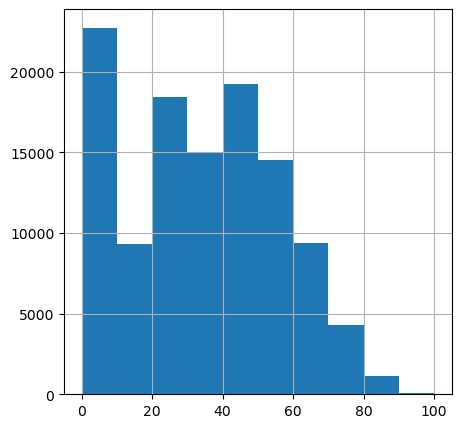

```python
data['popularity'].hist(figsize = (5,5));
```

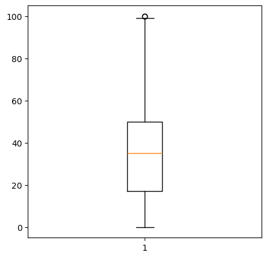

```python
plt.figure(figsize=(5, 5))
plt.boxplot(data['popularity']);
```

```python
data['popularity'].value_counts().head(2)
```

```
popularity
0     16020
22     2354
Name: count, dtype: int64
```

```python
data['popularity'].value_counts().tail(2)
```

```
popularity
100    2
99     1
Name: count, dtype: int64
```

```python
np.sort(data['popularity'].unique())
```

```
array([  0,   1,   2,   3,   4,   5,   6,   7,   8,   9,  10,  11,  12,
        13,  14,  15,  16,  17,  18,  19,  20,  21,  22,  23,  24,  25,
        26,  27,  28,  29,  30,  31,  32,  33,  34,  35,  36,  37,  38,
        39,  40,  41,  42,  43,  44,  45,  46,  47,  48,  49,  50,  51,
        52,  53,  54,  55,  56,  57,  58,  59,  60,  61,  62,  63,  64,
        65,  66,  67,  68,  69,  70,  71,  72,  73,  74,  75,  76,  77,
        78,  79,  80,  81,  82,  83,  84,  85,  86,  87,  88,  89,  90,
        91,  92,  93,  94,  95,  96,  97,  98,  99, 100], dtype=int64)
```

```python
data.isnull().sum()
```

```
Unnamed: 0          0
track_id            0
artists             1
album_name          1
track_name          1
popularity          0
duration_ms         0
explicit            0
danceability        0
energy              0
key                 0
loudness            0
mode                0
speechiness         0
acousticness        0
instrumentalness    0
liveness            0
valence             0
tempo               0
time_signature      0
track_genre         0
dtype: int64
```

```python
data[data['artists'].isnull()]
```

|  | Unnamed: 0 | track_id | artists | album_name | track_name | popularity | duration_ms | explicit | danceability | energy | key | loudness | mode | speechiness | acousticness | instrumentalness | liveness | valence | tempo | time_signature | track_genre |
| --- | --- | --- | --- | --- | --- | --- | --- | --- | --- | --- | --- | --- | --- | --- | --- | --- | --- | --- | --- | --- | --- |
| 65900 | 65900 | 1kR4gIb7nGxHPI3D2ifs59 | NaN | NaN | NaN | 0 | 0 | False | 0.501 | 0.583 | 7 | -9.46 | 0 | 0.0605 | 0.69 | 0.00396 | 0.0747 | 0.734 | 138.391 | 4 | k-pop |

```python
data.shape
```

```
(114000, 21)
```

Считали файл `dataset.csv`. Обнаружили 3 пропущенных значения в данных в столбцах `artists`, `album_name`, `track_name`, которые мы удалим. Проанализировали целевой признак `popularity`: большинство значений находятся в диапозоне 18-50, 16000 нулевых значений ( скорее всего, это не аномалия, а просто неактуальные песни ) и несколько значений 98-100. Явных дубликатов не обнаружили. Стоит удалить признак `Unnamed: 0`, так как он является номером каждой строки, а затем посмотреть на наличие дуюликатов.

# Шаг 2. Предобработка данных

```python
data_new = data.dropna()
```

```python
data_new.isnull().sum()
```

```
Unnamed: 0          0
track_id            0
artists             0
album_name          0
track_name          0
popularity          0
duration_ms         0
explicit            0
danceability        0
energy              0
key                 0
loudness            0
mode                0
speechiness         0
acousticness        0
instrumentalness    0
liveness            0
valence             0
tempo               0
time_signature      0
track_genre         0
dtype: int64
```

Удалили пропущенные значения.

```python
data_new = data_new.drop('Unnamed: 0', axis = 1)
```

Удалили ненужный признак Unnamed: 0

```python
data_new.duplicated().sum()
```

```
450
```

```python
data_new = data_new.drop_duplicates()
```

Удалили все явные дубликаты.

```python
data_new.duplicated().sum()
```

```
0
```

```python
data_new[data_new['popularity'] == 98].head(2)
```

|  | track_id | artists | album_name | track_name | popularity | duration_ms | explicit | danceability | energy | key | loudness | mode | speechiness | acousticness | instrumentalness | liveness | valence | tempo | time_signature | track_genre |
| --- | --- | --- | --- | --- | --- | --- | --- | --- | --- | --- | --- | --- | --- | --- | --- | --- | --- | --- | --- | --- |
| 20008 | 4uUG5RXrOk84mYEfFvj3cK | David Guetta;Bebe Rexha | I'm Good (Blue) | I'm Good (Blue) | 98 | 175238 | True | 0.561 | 0.965 | 7 | -3.673 | 0 | 0.0343 | 0.00383 | 0.000007 | 0.371 | 0.304 | 128.04 | 4 | dance |
| 30003 | 4uUG5RXrOk84mYEfFvj3cK | David Guetta;Bebe Rexha | I'm Good (Blue) | I'm Good (Blue) | 98 | 175238 | True | 0.561 | 0.965 | 7 | -3.673 | 0 | 0.0343 | 0.00383 | 0.000007 | 0.371 | 0.304 | 128.04 | 4 | edm |

```python
data_new['track_id'].duplicated().sum()
```

```
23809
```

```python
genres = data_new.groupby('track_id')['track_genre'].apply(list).reset_index()

data_new_1=data_new.copy()

data_new = data_new_1[['track_id', 'artists', 'album_name', 'track_name',\
       'popularity', 'duration_ms', 'explicit', 'danceability', 'energy',\
       'key', 'loudness', 'mode', 'speechiness', 'acousticness',\
       'instrumentalness', 'liveness', 'valence', 'tempo', 'time_signature',\
       ]].drop_duplicates()

data_new = data_new.merge(genres,on='track_id',how='left')
```

```python
data_new[['track_genre','track_id']].head(3)
```

|  | track_genre | track_id |
| --- | --- | --- |
| 0 | [acoustic, j-pop, singer-songwriter, songwriter] | 5SuOikwiRyPMVoIQDJUgSV |
| 1 | [acoustic, chill] | 4qPNDBW1i3p13qLCt0Ki3A |
| 2 | [acoustic] | 1iJBSr7s7jYXzM8EGcbK5b |

```python
data_new['explicit'] = data_new['explicit'].astype(int)
```

```python
data_new['multi_genre'] = data_new['track_genre'].apply(lambda x: 1 if len(x) > 1 else 0)
```

```python
data.shape
```

```
(114000, 21)
```

```python
data_new.shape
```

```
(90460, 21)
```

Мы сгруппировали датасет по id каждого трека, тем самым все жанры одного трека совместили в один список, который останеться в признаке track_genre. Также создали новй признак multi_genre, который будет отвечать за мультижанровость трека (если у трека один жанр, то 0, если 2 и больше, то 1).

```python
row_reduction_percentage = ((data.shape[0] - data_new.shape[0]) / data.shape[0]) * 100
f"Процент уменьшения строк: {row_reduction_percentage:.2f}%"
```

```
'Процент уменьшения строк: 20.65%'
```

Размер обработанного датасета data_new уменьшился в размере на 21%.

# Шаг 3. Исследовательский анализ данных

```python
def plot_hist_box(df, column, hist_title=None, box_title=None):
    fig, axes = plt.subplots(1, 2, figsize=(10, 4))

    sns.histplot(data=df[column], ax=axes[0])
    if hist_title is not None:
        axes[0].set_title(hist_title)

    sns.boxplot(data=df[column], ax=axes[1])
    if box_title is not None:
        axes[1].set_title(box_title)

    plt.show()
```

Написали функцию для визуализации количественных признаков при помощи гистограммы и боксплота.

```python
data_new.head(1)
```

|  | track_id | artists | album_name | track_name | popularity | duration_ms | explicit | danceability | energy | key | loudness | mode | speechiness | acousticness | instrumentalness | liveness | valence | tempo | time_signature | track_genre | multi_genre |
| --- | --- | --- | --- | --- | --- | --- | --- | --- | --- | --- | --- | --- | --- | --- | --- | --- | --- | --- | --- | --- | --- |
| 0 | 5SuOikwiRyPMVoIQDJUgSV | Gen Hoshino | Comedy | Comedy | 73 | 230666 | 0 | 0.676 | 0.461 | 1 | -6.746 | 0 | 0.143 | 0.0322 | 0.000001 | 0.358 | 0.715 | 87.917 | 4 | [acoustic, j-pop, singer-songwriter, songwriter] | 1 |

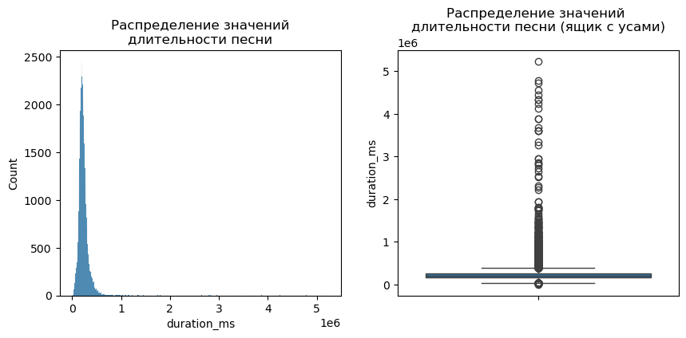

```python
plot_hist_box(data_new, 'duration_ms', '''Распределение значений
длительности песни''', '''Распределение значений
длительности песни (ящик с усами)''')
```

Все аномальные значения обьяснимы: некоторые песни могут быть очень долгими по времению.

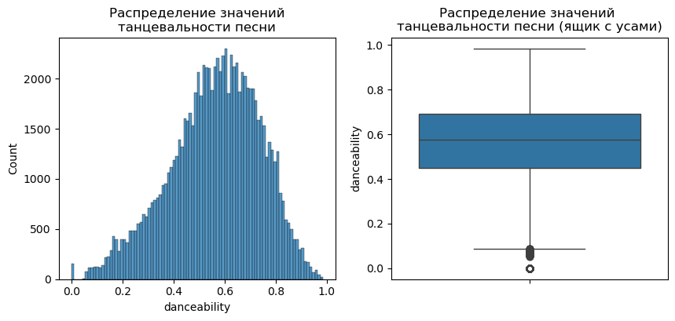

```python
plot_hist_box(data_new, 'danceability', '''Распределение значений
танцевальности песни''', '''Распределение значений
танцевальности песни (ящик с усами)''')
```

```python
data_new[data_new['danceability'] == 0].count()
```

```
track_id            157
artists             157
album_name          157
track_name          157
popularity          157
duration_ms         157
explicit            157
danceability        157
energy              157
key                 157
loudness            157
mode                157
speechiness         157
acousticness        157
instrumentalness    157
liveness            157
valence             157
tempo               157
time_signature      157
track_genre         157
multi_genre         157
dtype: int64
```

Присустсвует 157 нулевых значений "танцевальности" песен. Так и есть, ведь имеются песни с такими жанрами, как sleep, ambient и так далее.

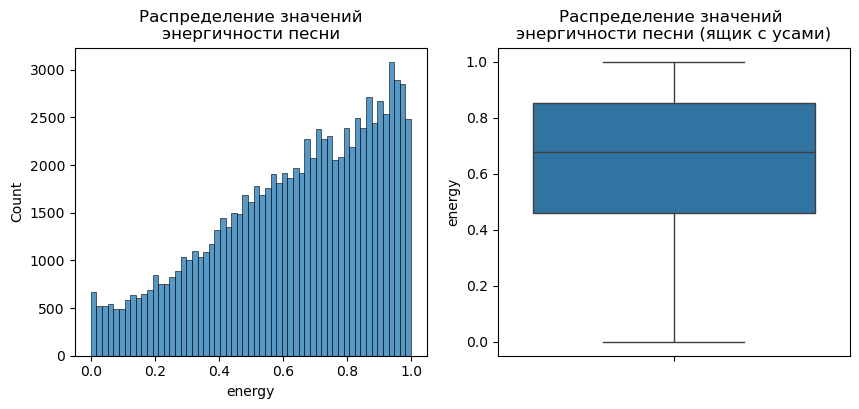

```python
plot_hist_box(data_new, 'energy', '''Распределение значений
энергичности песни''', '''Распределение значений
энергичности песни (ящик с усами)''')
```

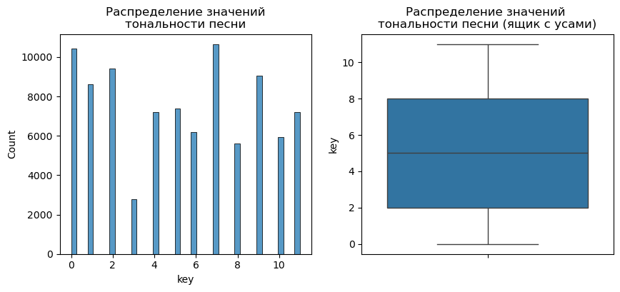

```python
plot_hist_box(data_new, 'key', '''Распределение значений
тональности песни''', '''Распределение значений
тональности песни (ящик с усами)''')
```

```python
data_new['loudness'].sort_values().head(2)
```

```
81290   -49.531
80943   -49.307
Name: loudness, dtype: float64
```

```python
data_new['loudness'].sort_values().tail()
```

```
34025    1.821
50862    1.864
34994    2.574
50750    3.156
16548    4.532
Name: loudness, dtype: float64
```

```python
data_new['loudness_new'] = ((data_new['loudness'] + 50) / 50)
```

```python
data_new.head(2)
```

|  | track_id | artists | album_name | track_name | popularity | duration_ms | explicit | danceability | energy | key | loudness | mode | speechiness | acousticness | instrumentalness | liveness | valence | tempo | time_signature | track_genre | multi_genre | loudness_new |
| --- | --- | --- | --- | --- | --- | --- | --- | --- | --- | --- | --- | --- | --- | --- | --- | --- | --- | --- | --- | --- | --- | --- |
| 0 | 5SuOikwiRyPMVoIQDJUgSV | Gen Hoshino | Comedy | Comedy | 73 | 230666 | 0 | 0.676 | 0.461 | 1 | -6.746 | 0 | 0.1430 | 0.0322 | 0.000001 | 0.358 | 0.715 | 87.917 | 4 | [acoustic, j-pop, singer-songwriter, songwriter] | 1 | 0.86508 |
| 1 | 4qPNDBW1i3p13qLCt0Ki3A | Ben Woodward | Ghost (Acoustic) | Ghost - Acoustic | 55 | 149610 | 0 | 0.420 | 0.166 | 1 | -17.235 | 1 | 0.0763 | 0.9240 | 0.000006 | 0.101 | 0.267 | 77.489 | 4 | [acoustic, chill] | 1 | 0.65530 |

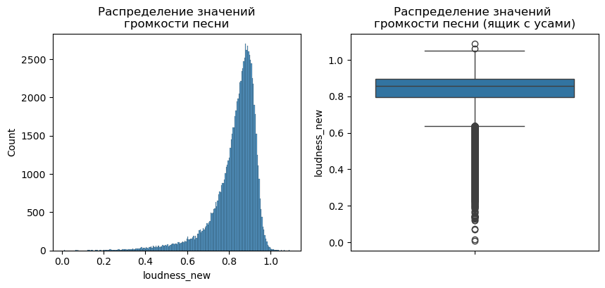

```python
plot_hist_box(data_new, 'loudness_new', '''Распределение значений
громкости песни''', '''Распределение значений
громкости песни (ящик с усами)''')
```

"Громкость" у некоторых песен меньше 0,2. Это песни с жанрами sleep, ambient и так далее, поэтому мы не считаем их за выбросы.

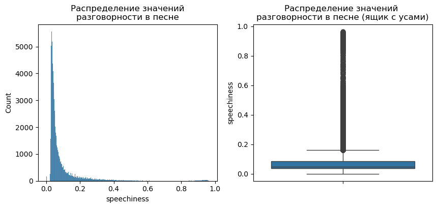

```python
plot_hist_box(data_new, 'speechiness', '''Распределение значений
разговорности в песне''', '''Распределение значений
разговорности в песне (ящик с усами)''')
```

"Разговорность" в песнях также могут достигать больших показателей в таких жанрах, как, например, рэп или комедия.

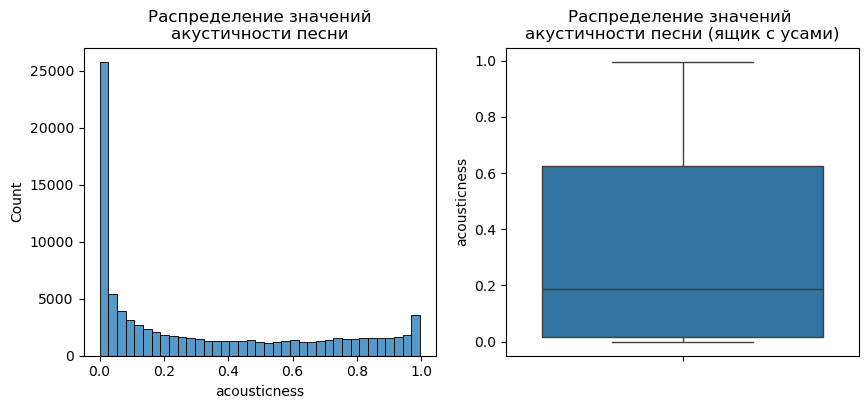

```python
plot_hist_box(data_new, 'acousticness', '''Распределение значений
акустичности песни''', '''Распределение значений
акустичности песни (ящик с усами)''')
```

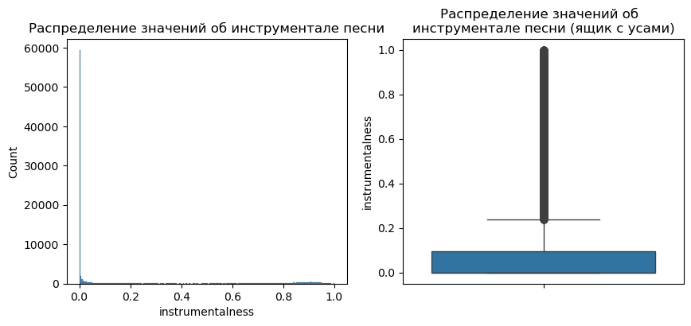

```python
plot_hist_box(data_new, 'instrumentalness', '''Распределение значений об инструментале песни''', '''Распределение значений об
инструментале песни (ящик с усами)''')
```

```python
data_new[data_new['instrumentalness'] > 0.4].count()
```

```
track_id            17780
artists             17780
album_name          17780
track_name          17780
popularity          17780
duration_ms         17780
explicit            17780
danceability        17780
energy              17780
key                 17780
loudness            17780
mode                17780
speechiness         17780
acousticness        17780
instrumentalness    17780
liveness            17780
valence             17780
tempo               17780
time_signature      17780
track_genre         17780
multi_genre         17780
loudness_new        17780
dtype: int64
```

[figure not shown]

```python
plot_hist_box(data_new, 'liveness', '''Распределение значений
длительности песни''', '''Распределение значений
длительности песни (ящик с усами)''')
```

[figure not shown]

```python
plot_hist_box(data_new, 'valence', '''Распределение значений
длительности песни''', '''Распределение значений
длительности песни (ящик с усами)''')
```

[figure not shown]

```python
plot_hist_box(data_new, 'tempo', '''Распределение значений
длительности песни''', '''Распределение значений
длительности песни (ящик с усами)''')
```

Скорость, с которой проигрывается песня, также может быть нулевая, например в жанре sleep, или высокая, например в жанре rap.

```python
data_new['positive'] = data_new[['danceability', 'energy', 'loudness_new', 'valence']].mean(axis=1)
```

```python
data_new.head(2)
```

|  | track_id | artists | album_name | track_name | popularity | duration_ms | explicit | danceability | energy | key | loudness | mode | speechiness | acousticness | instrumentalness | liveness | valence | tempo | time_signature | track_genre | multi_genre | loudness_new | positive |
| --- | --- | --- | --- | --- | --- | --- | --- | --- | --- | --- | --- | --- | --- | --- | --- | --- | --- | --- | --- | --- | --- | --- | --- |
| 0 | 5SuOikwiRyPMVoIQDJUgSV | Gen Hoshino | Comedy | Comedy | 73 | 230666 | 0 | 0.676 | 0.461 | 1 | -6.746 | 0 | 0.1430 | 0.0322 | 0.000001 | 0.358 | 0.715 | 87.917 | 4 | [acoustic, j-pop, singer-songwriter, songwriter] | 1 | 0.86508 | 0.679270 |
| 1 | 4qPNDBW1i3p13qLCt0Ki3A | Ben Woodward | Ghost (Acoustic) | Ghost - Acoustic | 55 | 149610 | 0 | 0.420 | 0.166 | 1 | -17.235 | 1 | 0.0763 | 0.9240 | 0.000006 | 0.101 | 0.267 | 77.489 | 4 | [acoustic, chill] | 1 | 0.65530 | 0.377075 |

Создали новый признак positive, который совмещает в себе "танцевальность", "энергичность", "громкость", "валентность" песни и отвечает за "позитивность" песни.

```python
def pie(sign, desc):
    fig, axs = plt.subplots(figsize=(5, 5))

    labels = data_new[sign].value_counts().index.tolist()
    axs.pie(data_new[sign].value_counts(), autopct='%1.1f%%', labels = labels)

    fig.suptitle(desc)

    plt.show()
```

Написали функцию для визуализации категориальных признаков при помощи круговой диаграммы.

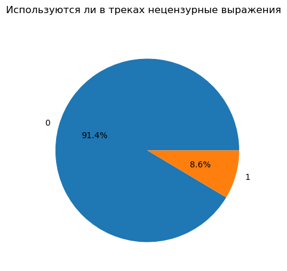

```python
pie('explicit', 'Используются ли в треках нецензурные выражения')
```

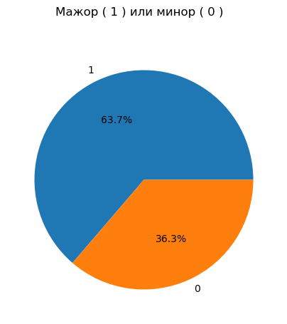

```python
pie('mode', 'Мажор ( 1 ) или минор ( 0 )')
```

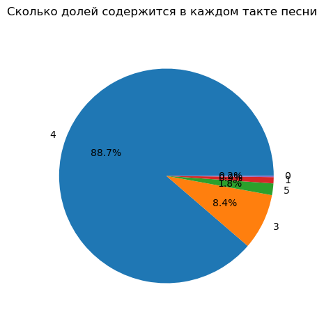

```python
pie('time_signature', 'Сколько долей содержится в каждом такте песни')
```

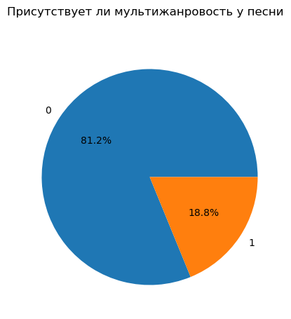

```python
pie('multi_genre', 'Присутствует ли мультижанровость у песни')
```

```python
numerical_col = data_new.select_dtypes(include=['number']).columns
```

```python
data_new[numerical_col].corr(method = 'spearman')
```

|  | popularity | duration_ms | explicit | danceability | energy | key | loudness | mode | speechiness | acousticness | instrumentalness | liveness | valence | tempo | time_signature | multi_genre | loudness_new | positive |
| --- | --- | --- | --- | --- | --- | --- | --- | --- | --- | --- | --- | --- | --- | --- | --- | --- | --- | --- |
| popularity | 1.000000 | 0.012277 | 0.049678 | 0.055143 | -0.016681 | 0.003413 | 0.065802 | -0.015576 | -0.067269 | 0.010849 | -0.123347 | -0.011348 | -0.011159 | 0.007717 | 0.041385 | 0.086496 | 0.065802 | 0.014489 |
| duration_ms | 0.012277 | 1.000000 | -0.092410 | -0.083380 | 0.114452 | 0.017222 | 0.031850 | -0.048964 | -0.124377 | -0.178217 | 0.119037 | -0.041568 | -0.169717 | 0.052987 | 0.030593 | -0.003347 | 0.031850 | -0.050771 |
| explicit | 0.049678 | -0.092410 | 1.000000 | 0.117994 | 0.088326 | 0.007366 | 0.109687 | -0.034107 | 0.269253 | -0.081458 | -0.127324 | 0.040370 | 0.000632 | -0.008027 | 0.044999 | -0.001151 | 0.109687 | 0.086051 |
| danceability | 0.055143 | -0.083380 | 0.117994 | 1.000000 | 0.049154 | 0.033466 | 0.114889 | -0.069140 | 0.152573 | -0.053088 | -0.156132 | -0.148902 | 0.475161 | -0.049321 | 0.183487 | 0.033414 | 0.114889 | 0.593288 |
| energy | -0.016681 | 0.114452 | 0.088326 | 0.049154 | 1.000000 | 0.043402 | 0.752668 | -0.070361 | 0.350064 | -0.711779 | -0.041905 | 0.181892 | 0.205338 | 0.250167 | 0.168434 | 0.031318 | 0.752668 | 0.642317 |
| key | 0.003413 | 0.017222 | 0.007366 | 0.033466 | 0.043402 | 1.000000 | 0.028451 | -0.139088 | 0.040304 | -0.040869 | 0.003610 | -0.006009 | 0.025321 | 0.008549 | 0.015383 | 0.009624 | 0.028451 | 0.045402 |
| loudness | 0.065802 | 0.031850 | 0.109687 | 0.114889 | 0.752668 | 0.028451 | 1.000000 | -0.039302 | 0.218028 | -0.536538 | -0.298595 | 0.114553 | 0.227083 | 0.209200 | 0.159546 | 0.077740 | 1.000000 | 0.605314 |
| mode | -0.015576 | -0.048964 | -0.034107 | -0.069140 | -0.070361 | -0.139088 | -0.039302 | 1.000000 | -0.108940 | 0.082846 | -0.077229 | 0.015433 | 0.024348 | -0.001276 | -0.027625 | 0.008740 | -0.039302 | -0.046815 |
| speechiness | -0.067269 | -0.124377 | 0.269253 | 0.152573 | 0.350064 | 0.040304 | 0.218028 | -0.108940 | 1.000000 | -0.214893 | -0.051506 | 0.094767 | 0.082848 | 0.109445 | 0.078693 | -0.027620 | 0.218028 | 0.255689 |
| acousticness | 0.010849 | -0.178217 | -0.081458 | -0.053088 | -0.711779 | -0.040869 | -0.536538 | 0.082846 | -0.214893 | 1.000000 | -0.095016 | -0.044962 | -0.022017 | -0.227433 | -0.163084 | -0.049697 | -0.536538 | -0.388209 |
| instrumentalness | -0.123347 | 0.119037 | -0.127324 | -0.156132 | -0.041905 | 0.003610 | -0.298595 | -0.077229 | -0.051506 | -0.095016 | 1.000000 | -0.105263 | -0.333767 | -0.012342 | -0.055592 | -0.077144 | -0.298595 | -0.276097 |
| liveness | -0.011348 | -0.041568 | 0.040370 | -0.148902 | 0.181892 | -0.006009 | 0.114553 | 0.015433 | 0.094767 | -0.044962 | -0.105263 | 1.000000 | 0.007707 | 0.014892 | -0.008783 | -0.017567 | 0.114553 | 0.038689 |
| valence | -0.011159 | -0.169717 | 0.000632 | 0.475161 | 0.205338 | 0.025321 | 0.227083 | 0.024348 | 0.082848 | -0.022017 | -0.333767 | 0.007707 | 1.000000 | 0.074989 | 0.131972 | 0.019442 | 0.227083 | 0.801343 |
| tempo | 0.007717 | 0.052987 | -0.008027 | -0.049321 | 0.250167 | 0.008549 | 0.209200 | -0.001276 | 0.109445 | -0.227433 | -0.012342 | 0.014892 | 0.074989 | 1.000000 | 0.027893 | 0.008481 | 0.209200 | 0.143938 |
| time_signature | 0.041385 | 0.030593 | 0.044999 | 0.183487 | 0.168434 | 0.015383 | 0.159546 | -0.027625 | 0.078693 | -0.163084 | -0.055592 | -0.008783 | 0.131972 | 0.027893 | 1.000000 | 0.025064 | 0.159546 | 0.215648 |
| multi_genre | 0.086496 | -0.003347 | -0.001151 | 0.033414 | 0.031318 | 0.009624 | 0.077740 | 0.008740 | -0.027620 | -0.049697 | -0.077144 | -0.017567 | 0.019442 | 0.008481 | 0.025064 | 1.000000 | 0.077740 | 0.041932 |
| loudness_new | 0.065802 | 0.031850 | 0.109687 | 0.114889 | 0.752668 | 0.028451 | 1.000000 | -0.039302 | 0.218028 | -0.536538 | -0.298595 | 0.114553 | 0.227083 | 0.209200 | 0.159546 | 0.077740 | 1.000000 | 0.605314 |
| positive | 0.014489 | -0.050771 | 0.086051 | 0.593288 | 0.642317 | 0.045402 | 0.605314 | -0.046815 | 0.255689 | -0.388209 | -0.276097 | 0.038689 | 0.801343 | 0.143938 | 0.215648 | 0.041932 | 0.605314 | 1.000000 |

Создали корреляцию количественных признаков от тагрета (popularity). Большинство признаков не превышает корреляцию 0,1.

```python
categorical_col = ['artists', 'album_name', 'track_name']

data_cat = data_new.copy()

label_encoders = {}
for col in categorical_col:
    le = LabelEncoder()
    data_cat[col] = le.fit_transform(data_cat[col])
    label_encoders[col] = le
```

```python
data_new.head(2)
```

|  | track_id | artists | album_name | track_name | popularity | duration_ms | explicit | danceability | energy | key | loudness | mode | speechiness | acousticness | instrumentalness | liveness | valence | tempo | time_signature | track_genre | multi_genre | loudness_new | positive |
| --- | --- | --- | --- | --- | --- | --- | --- | --- | --- | --- | --- | --- | --- | --- | --- | --- | --- | --- | --- | --- | --- | --- | --- |
| 0 | 5SuOikwiRyPMVoIQDJUgSV | Gen Hoshino | Comedy | Comedy | 73 | 230666 | 0 | 0.676 | 0.461 | 1 | -6.746 | 0 | 0.1430 | 0.0322 | 0.000001 | 0.358 | 0.715 | 87.917 | 4 | [acoustic, j-pop, singer-songwriter, songwriter] | 1 | 0.86508 | 0.679270 |
| 1 | 4qPNDBW1i3p13qLCt0Ki3A | Ben Woodward | Ghost (Acoustic) | Ghost - Acoustic | 55 | 149610 | 0 | 0.420 | 0.166 | 1 | -17.235 | 1 | 0.0763 | 0.9240 | 0.000006 | 0.101 | 0.267 | 77.489 | 4 | [acoustic, chill] | 1 | 0.65530 | 0.377075 |

```python
data_cat[['popularity', 'artists', 'album_name', 'track_name']].corr()
```

|  | popularity | artists | album_name | track_name |
| --- | --- | --- | --- | --- |
| popularity | 1.000000 | -0.000725 | 0.029200 | 0.007155 |
| artists | -0.000725 | 1.000000 | 0.096396 | 0.044169 |
| album_name | 0.029200 | 0.096396 | 1.000000 | 0.315269 |
| track_name | 0.007155 | 0.044169 | 0.315269 | 1.000000 |

Создали корреляцию категориальных признаков от тагрета (popularity). Все признаки имеют плохую корреляцию.

# Шаг 4. Подготовка данных

```python
data_new.head(2)
```

|  | track_id | artists | album_name | track_name | popularity | duration_ms | explicit | danceability | energy | key | loudness | mode | speechiness | acousticness | instrumentalness | liveness | valence | tempo | time_signature | track_genre | multi_genre | loudness_new | positive |
| --- | --- | --- | --- | --- | --- | --- | --- | --- | --- | --- | --- | --- | --- | --- | --- | --- | --- | --- | --- | --- | --- | --- | --- |
| 0 | 5SuOikwiRyPMVoIQDJUgSV | Gen Hoshino | Comedy | Comedy | 73 | 230666 | 0 | 0.676 | 0.461 | 1 | -6.746 | 0 | 0.1430 | 0.0322 | 0.000001 | 0.358 | 0.715 | 87.917 | 4 | [acoustic, j-pop, singer-songwriter, songwriter] | 1 | 0.86508 | 0.679270 |
| 1 | 4qPNDBW1i3p13qLCt0Ki3A | Ben Woodward | Ghost (Acoustic) | Ghost - Acoustic | 55 | 149610 | 0 | 0.420 | 0.166 | 1 | -17.235 | 1 | 0.0763 | 0.9240 | 0.000006 | 0.101 | 0.267 | 77.489 | 4 | [acoustic, chill] | 1 | 0.65530 | 0.377075 |

```python
X = data_new.drop(['popularity',
                   'track_id',
                   'duration_ms',
                   'energy',
                   'key',
                   'acousticness',
                   'tempo',
                   'album_name',
                   'track_name',
                   'loudness',
                   'mode',
                  'liveness'] ,axis = 1)
y = data_new['popularity']
X_train, X_test, y_train, y_test = train_test_split(X,
                                                    y,
                                                    test_size=0.2,
                                                    random_state=42)
```

```python
X_test.head()
```

|  | artists | explicit | danceability | speechiness | instrumentalness | valence | time_signature | track_genre | multi_genre | loudness_new | positive |
| --- | --- | --- | --- | --- | --- | --- | --- | --- | --- | --- | --- |
| 43156 | The Bouncing Souls | 0 | 0.439 | 0.0693 | 0.000007 | 0.607 | 4 | [hardcore] | 0 | 0.94718 | 0.739795 |
| 85629 | Juan D'Arienzo;Alberto Echagüe | 0 | 0.580 | 0.0971 | 0.000088 | 0.704 | 4 | [tango] | 0 | 0.88208 | 0.704020 |
| 74545 | Kvatro | 0 | 0.335 | 0.0353 | 0.000070 | 0.195 | 4 | [romance] | 0 | 0.85454 | 0.419135 |
| 70848 | Korol i Shut | 0 | 0.304 | 0.0634 | 0.000000 | 0.353 | 4 | [punk-rock] | 0 | 0.88796 | 0.577240 |
| 90264 | Buena Vista Social Club | 0 | 0.630 | 0.0406 | 0.000186 | 0.963 | 4 | [world-music] | 0 | 0.78416 | 0.709790 |

```python
X_train.info()
```

```
<class 'pandas.core.frame.DataFrame'>
Index: 72368 entries, 87525 to 15795
Data columns (total 11 columns):
 #   Column            Non-Null Count  Dtype
---  ------            --------------  -----
 0   artists           72368 non-null  object
 1   explicit          72368 non-null  int32
 2   danceability      72368 non-null  float64
 3   speechiness       72368 non-null  float64
 4   instrumentalness  72368 non-null  float64
 5   valence           72368 non-null  float64
 6   time_signature    72368 non-null  int64
 7   track_genre       72368 non-null  object
 8   multi_genre       72368 non-null  int64
 9   loudness_new      72368 non-null  float64
 10  positive          72368 non-null  float64
dtypes: float64(6), int32(1), int64(2), object(2)
memory usage: 6.3+ MB
```

```python
X_train.columns
```

```
Index(['artists', 'explicit', 'danceability', 'speechiness',
       'instrumentalness', 'valence', 'time_signature', 'track_genre',
       'multi_genre', 'loudness_new', 'positive'],
      dtype='object')
```

```python
print(X_train.shape, X_test.shape)
print(y_train.shape, y_test.shape)
```

```
(72368, 11) (18092, 11)
(72368,) (18092,)
```

```python
X_col_num = X.select_dtypes(include=['number']).columns
```

```python
num_columns = X_col_num
ohe_columns = ['artists']
mlb_columns = ['track_genre']
```

```python
num_columns
```

```
Index(['explicit', 'danceability', 'speechiness', 'instrumentalness',
       'valence', 'time_signature', 'multi_genre', 'loudness_new', 'positive'],
      dtype='object')
```

```python
ohe_columns
```

```
['artists']
```

```python
mlb_columns
```

```
['track_genre']
```

Подготовили тренировочную и тестовую выборки: 80% на 20% от всей выборки соотвественно. В качестве количественных признаков выбрали: 'explicit', 'danceability', 'speechiness', 'instrumentalness', 'valence', 'time_signature', 'multi_genre', 'loudness_new', 'positive'. У таких признаков, как 'duration_ms','energy','key','acousticness','tempo', 'loudness','mode','liveness' корреляция с таргетом практически нулевая. В качестве категориальных признаков выбрали artists и track_genre.

# Шаг 5. Обучение моделей

Создадим один пайплайн с предобработкой для будущих моделей.

```python
def binarize_genres(genres):
    mlb = MultiLabelBinarizer()
    return mlb.fit_transform(genres)
```

```python
X_train['track_genre'] = X_train['track_genre'].apply(lambda x: x if isinstance(x, list) else [x])
```

Для обработки признака track_genre перед обучением нужно масштабировать все строки с помощью MultiLabelBinarizer, так как каждая строки - это массив меток. Для этого создали функцию binarize_genres, которая автоматически масштабирует все строки. Также проверили признак track_genre на наличие пустых списков. Затем нужно вставить в пайплайн с помощью FunctionTransformer.

```python
data_preprocessor = ColumnTransformer(
    transformers=[
        ('num', StandardScaler(), num_columns),
        ('track_genre', FunctionTransformer(binarize_genres, validate=False), 'track_genre'),
        ('ohe', OneHotEncoder(handle_unknown='ignore', sparse_output=True), ohe_columns)
    ],
    remainder='passthrough'
)
# Основная модель
pipeline = Pipeline([
    ('preprocessor', data_preprocessor),
    ('model', DecisionTreeRegressor())
])
```

```python
pipeline.set_params(model__max_depth=5)  # Set max_depth for DecisionTreeRegressor
```

```
Pipeline(steps=[('preprocessor',
                 ColumnTransformer(remainder='passthrough',
                                   transformers=[('num', StandardScaler(),
                                                  Index(['explicit', 'danceability', 'speechiness', 'instrumentalness',
       'valence', 'time_signature', 'multi_genre', 'loudness_new', 'positive'],
      dtype='object')),
                                                 ('track_genre',
                                                  FunctionTransformer(func=<function binarize_genres at 0x00000206B1E23E20>),
                                                  'track_genre'),
                                                 ('ohe',
                                                  OneHotEncoder(handle_unknown='ignore'),
                                                  ['artists'])])),
                ('model', DecisionTreeRegressor(max_depth=5))])
```

Количественные данные масштабировали с помощью StandardScaler, категориальные - OneHotEncoder, а массив меток - MultiLabelBinarizer. Теперь обучаем 4 модели:

```
- линейную регрессию

- модель градиентного бустинга

- дерево решений

- нейронную сеть
```

`LinearRegression`

```python
param_grid_1 = [
    {
        'model': [LinearRegression()]
    }
]
```

```python
rs_1 = RandomizedSearchCV(
    pipeline,
    param_distributions=param_grid_1,
    cv=5,
    scoring='neg_mean_absolute_error',
    n_jobs=-1,
    random_state = 42
)
```

```python
print(X_train.columns)
print(num_columns)
print(ohe_columns)
print(mlb_columns)
```

```
Index(['artists', 'explicit', 'danceability', 'speechiness',
       'instrumentalness', 'valence', 'time_signature', 'track_genre',
       'multi_genre', 'loudness_new', 'positive'],
      dtype='object')
Index(['explicit', 'danceability', 'speechiness', 'instrumentalness',
       'valence', 'time_signature', 'multi_genre', 'loudness_new', 'positive'],
      dtype='object')
['artists']
['track_genre']
```

```python
start_time_1 = time.time()
rs_1.fit(X_train, y_train)
end_time_1 = time.time()
gs_time_1 = end_time_1 - start_time_1
```

```python
y_pred_1 = rs_1.predict(X_test)
```

```python
mae_1 = mean_absolute_error(y_test, y_pred_1)
mse_1 = mean_squared_error(y_test, y_pred_1)
r2_1 = r2_score(y_test, y_pred_1)
rmse_1 = mse_1 ** 0.5
```

`GradientBoostingRegressor`

```python
param_grid_2 = [
    {
        'model': [GradientBoostingRegressor()],
        'model__max_depth': [3, 5, 7]
    }
]
```

```python
rs_2 = RandomizedSearchCV(
    pipeline,
    param_distributions=param_grid_2,
    cv=5,
    scoring='neg_mean_absolute_error',
    n_jobs=-1,
    random_state = RANDOM_STATE
)
```

```python
start_time_2 = time.time()
rs_2.fit(X_train, y_train)
end_time_2 = time.time()
gs_time_2 = end_time_2 - start_time_2
```

```python
y_pred_2 = rs_2.predict(X_test)
```

```python
mae_2 = mean_absolute_error(y_test, y_pred_2)
mse_2 = mean_squared_error(y_test, y_pred_2)
r2_2 = r2_score(y_test, y_pred_2)
rmse_2 = mse_2 ** 0.5
```

[output not shown]

`DecisionTreeRegressor`

```python
param_grid_3 = [
    {
        'model': [DecisionTreeRegressor(random_state = RANDOM_STATE)],
        'model__max_depth': [None, 10, 20, 30],
        'model__min_samples_split': [2, 5, 10],
        'model__min_samples_leaf': [1, 2, 4]
    }
]
```

```python
rs_3 = RandomizedSearchCV(
    pipeline,
    param_grid_3,
    cv=5,
    scoring='neg_mean_absolute_error',
    n_jobs=-1,
    random_state = RANDOM_STATE
)
```

```python
start_time_3 = time.time()
rs_3.fit(X_train, y_train)
end_time_3 = time.time()
gs_time_3 = end_time_3 - start_time_3
```

```python
y_pred_3 = rs_3.predict(X_test)
```

```python
mae_3 = mean_absolute_error(y_test, y_pred_3)
mse_3 = mean_squared_error(y_test, y_pred_3)
r2_3 = r2_score(y_test, y_pred_3)
rmse_3 = mse_3 ** 0.5
```

`Keras`

```python
from scikeras.wrappers import KerasRegressor
from tensorflow import keras
from tensorflow.keras import layers
```

```python
def create_mlp_model(optimizer='adam', neurons=64):
    model = keras.Sequential()
    model.add(layers.Dense(neurons, activation='relu', input_shape=(27411,)))
    model.add(layers.Dense(neurons, activation='relu'))
    model.add(layers.Dense(1))
    model.compile(optimizer=optimizer, loss='mean_squared_error')
    return model

mlp_model = KerasRegressor(model=create_mlp_model, epochs=10, batch_size=32,validation_split=0.2)
```

```python
X_train.shape[0]
```

```
72368
```

```python
data_preprocessor = ColumnTransformer(
    transformers=[
        ('num', StandardScaler(), num_columns),
        ('track_genre', FunctionTransformer(binarize_genres, validate=False), 'track_genre'),
        ('ohe', OneHotEncoder(handle_unknown='ignore', sparse_output=True), ohe_columns)
    ],
    remainder='passthrough'
)

rs_4 = Pipeline([
    ('preprocessor', data_preprocessor),
    ('model', mlp_model)
])
```

```python
start_time_4 = time.time()
rs_4.fit(X_train, y_train)
end_time_4 = time.time()
gs_time_4 = end_time_4 - start_time_4
```

```
1810/1810 ━━━━━━━━━━━━━━━━━━━━ 16s 9ms/step - loss: 519.7198 - val_loss: 221.1780
1810/1810 ━━━━━━━━━━━━━━━━━━━━ 15s 9ms/step - loss: 177.7547 - val_loss: 199.1008
1810/1810 ━━━━━━━━━━━━━━━━━━━━ 16s 9ms/step - loss: 126.7079 - val_loss: 196.6810
1810/1810 ━━━━━━━━━━━━━━━━━━━━ 16s 9ms/step - loss: 103.3375 - val_loss: 196.6169
1810/1810 ━━━━━━━━━━━━━━━━━━━━ 16s 9ms/step - loss: 90.8278 - val_loss: 194.7664
1810/1810 ━━━━━━━━━━━━━━━━━━━━ 15s 8ms/step - loss: 84.8089 - val_loss: 192.2399
1810/1810 ━━━━━━━━━━━━━━━━━━━━ 17s 9ms/step - loss: 75.6086 - val_loss: 194.0194
1810/1810 ━━━━━━━━━━━━━━━━━━━━ 18s 10ms/step - loss: 70.5316 - val_loss: 194.5135
1810/1810 ━━━━━━━━━━━━━━━━━━━━ 18s 10ms/step - loss: 71.7840 - val_loss: 192.5653
1810/1810 ━━━━━━━━━━━━━━━━━━━━ 19s 10ms/step - loss: 66.1611 - val_loss: 192.5987
```

```python
y_pred_4 = rs_4.predict(X_test)
```

```
566/566 ━━━━━━━━━━━━━━━━━━━━ 1s 1ms/step
```

```python
mae_4 = mean_absolute_error(y_test, y_pred_4)
mse_4 = mean_squared_error(y_test, y_pred_4)
r2_4 = r2_score(y_test, y_pred_4)
rmse_4 = mse_4 ** 0.5
```